# Week 4 In-Class Lab

September 21, 2020

# 1 Goals

In this in-class lab, we will revisit KDE and PCA.

# 2 KDE

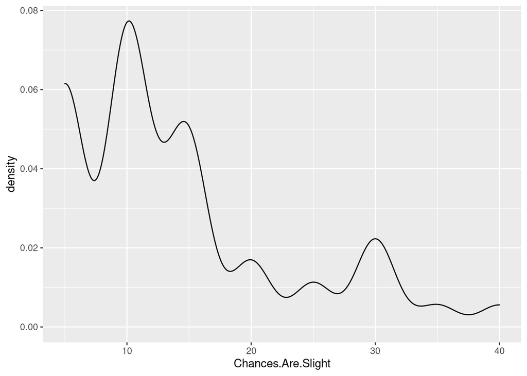

You will implement at least two kernel functions of your choice and then estimate the density of the `Chances.Are.Slight` variables in `perceptions`. Please complete the implementations of `Kernel1()` and `Kernel2()` to use in `EstimateDensity()` in the file `R/kernel_density_fncts.R`. Here are some kernels you may want to try:

$$\text{Square kernel: } K(x) = 1\{|x| < 1/2\}$$

$$\text{Gaussian kernel: } K(x) = \frac{1}{\sqrt{2\pi}} \exp\{-x^2/2\}$$

$$\text{Epanechnikov kernel: } K(x) = \begin{cases}
\frac{3}{4}(1 - x^2/5)/\sqrt{5}, & |x| < \sqrt{5} \\
0 & o.w
\end{cases}$$

Once you’ve implemented the kernels, plot them below, showing various values of $h$ for each kernel function. What do you think has a more important influence on the impression given by the plot: the kernel function or the value of $h$?

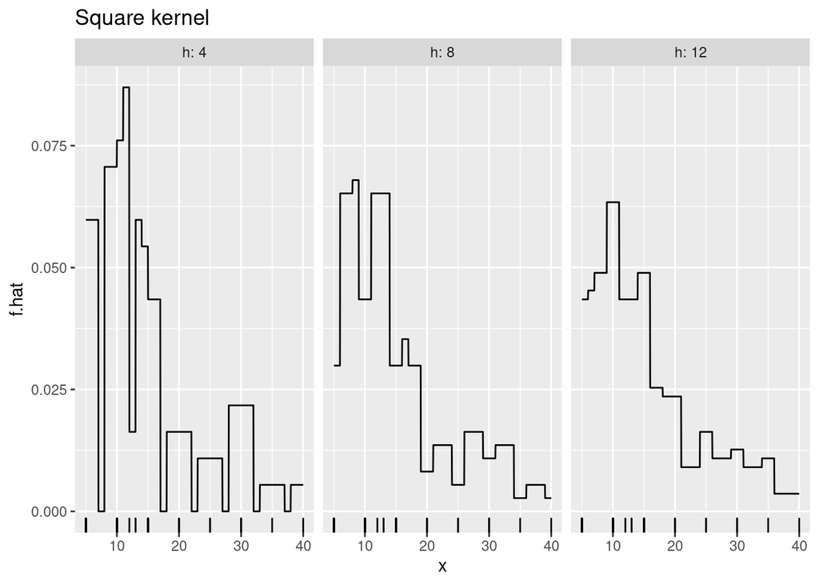

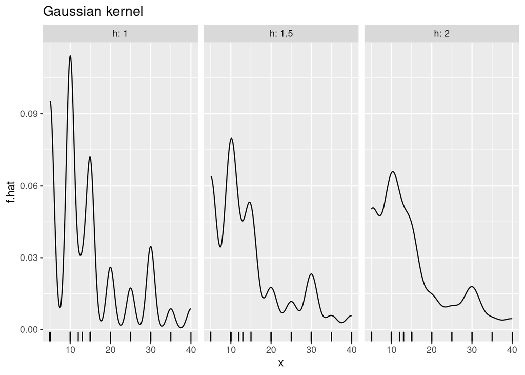

# 3 PCA

[This section thanks to Tiffany Tang.]

For our exploration of PCA, we will be looking at gene expression data, obtained from [The Cancer Genome Atlas](https://www.cancer.gov/about-nci/organization/ccg/research/structural-genomics/tcga), for various patients with breast cancer (BRCA). The genomic basis of breast cancer has been extensively studied in the scientific literature, and in particular, scientists have classified breast cancer occurrences into four different subtypes - each with its own defining characteristics and clinical implications (The Cancer Genome Atlas Research Network 2012).

```
## 'data.frame':    241 obs. of  17814 variables:
##  $ ELMO2          : num  0.1814 0.4615 0.877 1.4123 -0.0759 ...
##  $ CREB3L1        : num  0.891 2.259 0.438 -0.637 -0.708 ...
##  $ RPS11          : num  0.716 0.417 0.115 0.493 -0.169 ...
##  $ PNMA1          : num  0.1318 0.325 0.7578 0.9433 -0.0643 ...
##  $ MMP2           : num  0.9578 2.2855 -0.0893 -1.2332 -1.3965 ...
##  $ C10orf90       : num  -0.59 -1.73 -1.78 -2.75 -2.27 ...
##  $ ZHX3           : num  -0.0437 0.4205 0.251 -1.3315 -0.9075 ...
##  $ ERCC5          : num  -0.2385 0.00725 0.03525 0.791 -0.1365 ...
##  $ GPR98          : num  -0.1522 -0.696 -0.6406 0.0145 -0.7439 ...
##  $ RXFP3          : num  0.443 0.296 0.689 -0.06 0.831 ...
##  $ APBB2          : num  1.525 2.127 2.107 0.956 -0.348 ...
##  $ PRO0478        : num  -1.2 -1.42 -1.21 -1.31 -1.31 ...
##  $ KLHL13         : num  0.4612 -0.0005 -1.7125 -0.7518 -2.5315 ...
##  $ PRSSL1         : num  -0.771 -0.685 -0.189 -1.367 -0.849 ...
```

[output cut: 86 more lines]

```
## 'data.frame':    241 obs. of  2 variables:
##  $ BRCA_Subtype_PAM50: Factor w/ 4 levels "Basal","Her2",..: 3 3 3 1 1 1 3 1 4 1 ...
##  $ vital_status      : Factor w/ 2 levels "Alive","Dead": 1 1 1 2 1 1 1 2 1 1 ...
```

To perform PCA, we use the function `prcomp()` in R. In the output of `prcomp()`, `rotation` gives the PC loadings and `x` gives the PC scores, so we can plot the first two PCs with points colored by their breast cancer subtype as follows. Feel free to play around with the center and scale arguments to see how this affects the results.

```
## List of 5
##  $ sdev    : num [1:241] 38.1 26.1 21.4 18.8 16.3 ...
##  $ rotation: num [1:17814, 1:241] -0.00443 -0.00826 0.00133 -0.00673 -0.00344 ...
##   ..- attr(*, "dimnames")=List of 2
##   .. ..$ : chr [1:17814] "ELMO2" "CREB3L1" "RPS11" "PNMA1" ...
##   .. ..$ : chr [1:241] "PC1" "PC2" "PC3" "PC4" ...
##  $ center  : Named num [1:17814] 0.3126 0.8329 0.4004 0.0544 0.2871 ...
##   ..- attr(*, "names")= chr [1:17814] "ELMO2" "CREB3L1" "RPS11" "PNMA1" ...
##  $ scale   : logi FALSE
##  $ x       : num [1:241, 1:241] -24.2 -13.6 -12.7 50.2 60.6 ...
##   ..- attr(*, "dimnames")=List of 2
##   .. ..$ : chr [1:241] "TCGA-A1-A0SE" "TCGA-A1-A0SH" "TCGA-A1-A0SJ" "TCGA-A1-A0SK" ...
##   .. ..$ : chr [1:241] "PC1" "PC2" "PC3" "PC4" ...
##  - attr(*, "class")= chr "prcomp"
```

```
## Importance of components:
##                            PC1      PC2     PC3      PC4      PC5      PC6
## Standard deviation     38.0814 26.09774 21.4219 18.76365 16.31004 14.84651
## Proportion of Variance  0.1381  0.06486  0.0437  0.03353  0.02533  0.02099
## Cumulative Proportion   0.1381  0.20296  0.2467  0.28019  0.30552  0.32651
##                             PC7      PC8     PC9    PC10     PC11     PC12
## Standard deviation     14.20442 13.76456 12.8412 11.7282 11.55756 11.33735
## Proportion of Variance  0.01921  0.01804  0.0157  0.0131  0.01272  0.01224
## Cumulative Proportion   0.34573  0.36377  0.3795  0.3926  0.40529  0.41753
##                            PC13     PC14     PC15     PC16    PC17    PC18
## Standard deviation     10.92031 10.76756 10.34023 10.02799 9.98213 9.64994
## Proportion of Variance  0.01136  0.01104  0.01018  0.00958 0.00949 0.00887
## Cumulative Proportion   0.42889  0.43993  0.45011  0.45969 0.46918 0.47805
##                           PC19    PC20    PC21    PC22    PC23    PC24    PC25
## Standard deviation     9.52209 9.34524 9.01502 8.92446 8.84150 8.67422 8.55309
## Proportion of Variance 0.00863 0.00832 0.00774 0.00758 0.00744 0.00717 0.00697
## Cumulative Proportion  0.48668 0.49500 0.50274 0.51032 0.51777 0.52493 0.53190
##                           PC26    PC27    PC28   PC29    PC30    PC31   PC32
## Standard deviation     8.47651 8.38429 8.27346 8.1308 8.12732 7.92413 7.8034
## Proportion of Variance 0.00684 0.00669 0.00652 0.0063 0.00629 0.00598 0.0058
## Cumulative Proportion  0.53874 0.54543 0.55195 0.5583 0.56454 0.57052 0.5763
##                           PC33    PC34    PC35    PC36    PC37    PC38    PC39
## Standard deviation     7.70076 7.60362 7.53785 7.46570 7.29858 7.21493 7.19131
## Proportion of Variance 0.00565 0.00551 0.00541 0.00531 0.00507 0.00496 0.00492
## Cumulative Proportion  0.58196 0.58747 0.59288 0.59819 0.60326 0.60822 0.61314
##                           PC40   PC41    PC42    PC43    PC44    PC45    PC46
## Standard deviation     7.14617 7.1014 7.06473 6.99845 6.98809 6.82464 6.76803
## Proportion of Variance 0.00486 0.0048 0.00475 0.00466 0.00465 0.00444 0.00436
## Cumulative Proportion  0.61801 0.6228 0.62756 0.63223 0.63688 0.64131 0.64567
##                           PC47    PC48   PC49    PC50    PC51   PC52    PC53
## Standard deviation     6.75841 6.68621 6.6414 6.57415 6.49009 6.4813 6.41509
## Proportion of Variance 0.00435 0.00426 0.0042 0.00412 0.00401 0.0040 0.00392
## Cumulative Proportion  0.65002 0.65428 0.6585 0.66260 0.66661 0.6706 0.67453
##                           PC54    PC55    PC56    PC57    PC58    PC59    PC60
## Standard deviation     6.35612 6.28560 6.24116 6.20529 6.15783 6.10906 6.07270
## Proportion of Variance 0.00385 0.00376 0.00371 0.00367 0.00361 0.00355 0.00351
## Cumulative Proportion  0.67838 0.68214 0.68585 0.68951 0.69312 0.69668 0.70019
##                           PC61    PC62    PC63    PC64    PC65    PC66    PC67
## Standard deviation     6.04388 5.99479 5.94263 5.92170 5.90560 5.85730 5.82582
## Proportion of Variance 0.00348 0.00342 0.00336 0.00334 0.00332 0.00327 0.00323
```

[output cut: 86 more lines]

```
## Standard deviation     3.01890 3.01759 3.00132 2.99198 2.97103 2.94812 2.92827
## Proportion of Variance 0.00087 0.00087 0.00086 0.00085 0.00084 0.00083 0.00082
## Cumulative Proportion  0.98172 0.98259 0.98344 0.98430 0.98514 0.98597 0.98678
##                          PC222  PC223   PC224   PC225   PC226   PC227   PC228
## Standard deviation     2.91943 2.8930 2.88477 2.86457 2.83342 2.79998 2.78152
## Proportion of Variance 0.00081 0.0008 0.00079 0.00078 0.00076 0.00075 0.00074
## Cumulative Proportion  0.98759 0.9884 0.98918 0.98996 0.99073 0.99148 0.99221
##                          PC229   PC230  PC231   PC232   PC233   PC234   PC235
## Standard deviation     2.76163 2.75671 2.7025 2.68935 2.66769 2.62308 2.60188
## Proportion of Variance 0.00073 0.00072 0.0007 0.00069 0.00068 0.00066 0.00064
## Cumulative Proportion  0.99294 0.99366 0.9944 0.99505 0.99572 0.99638 0.99702
##                          PC236   PC237  PC238   PC239   PC240     PC241
## Standard deviation     2.56467 2.54229 2.5186 2.46778 2.40226 7.702e-15
## Proportion of Variance 0.00063 0.00062 0.0006 0.00058 0.00055 0.000e+00
## Cumulative Proportion  0.99765 0.99827 0.9989 0.99945 1.00000 1.000e+00
```

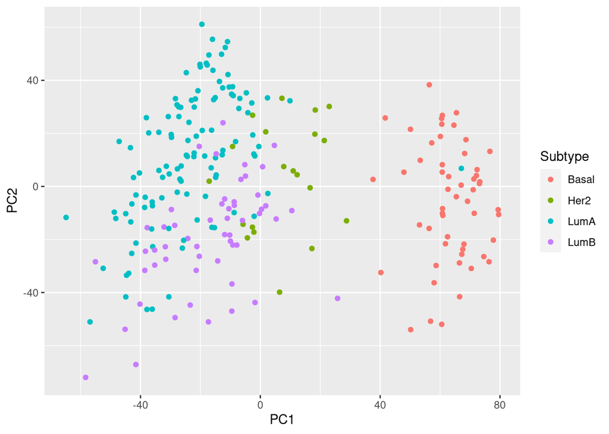

```
##      Gene         PC1
## 1    AGR3 -0.08650272
## 2    ESR1 -0.06711224
## 3   FOXA1 -0.06434495
## 4    AGR2 -0.06258967
## 5 C1orf64 -0.05858960
## 6   ROPN1  0.05679449
```

1. Create a plot with the cumulative proportion of variance explained on the y-axis and the number of PCs on the x-axis. How many PCs do you need to retain $75\%$ of the variation in the data?

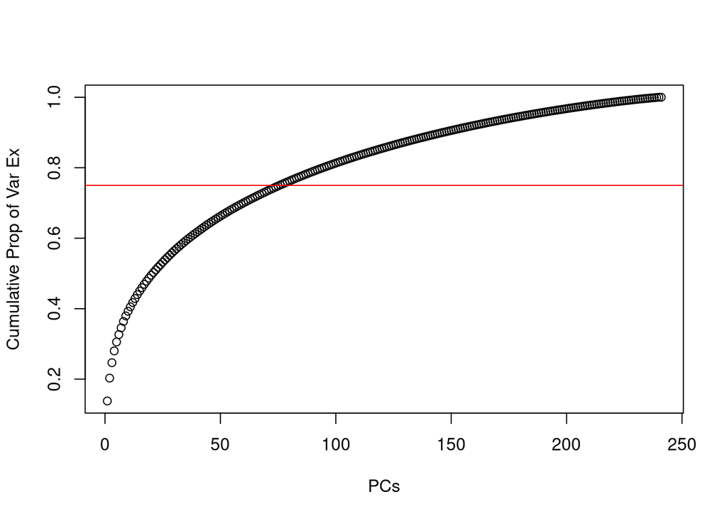

```
## [1] 76
```

But rather than using `prcomp()`, we can also code up PCA directly by computing the SVD using `svd()`.

2. Take the SVD of `X` and recreate the PC1 vs. PC2 plot. Compare your plot with the above plot that was created using `prcomp`.

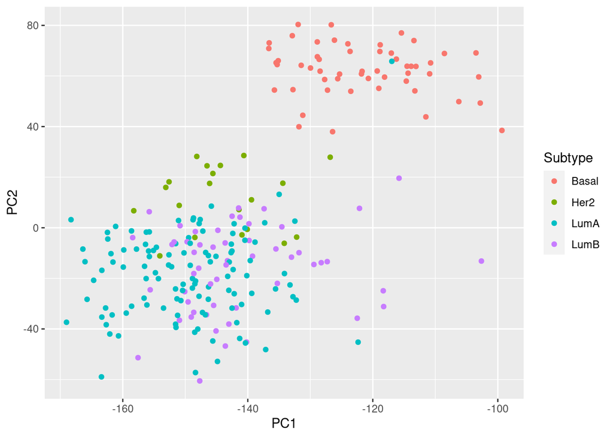

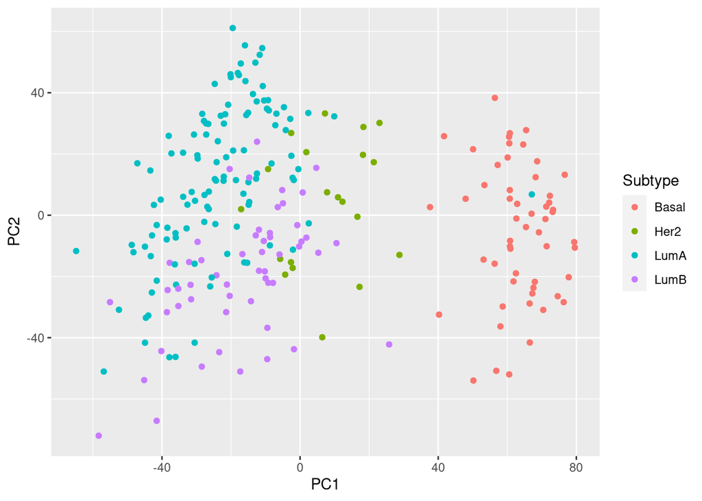

Given that there is already a built-in R function, `prcomp()`, for performing PCA, there does not seem to be any advantage to using `svd()` over `prcomp()`. However, there is a huge advantage of knowing the relationship between the SVD and PCA because in practice, you typically only need to compute the first few PCs, not all PCs. As a result, you can use really fast algorithms to compute the first few PCs, or equivalently the first few singular vectors, and improve upon the computational complexity of `prcomp()`. This is particularly useful when you have incredibly large datasets. One function for computing the top singular vectors of a matrix is `irlba()` from the `irlba` package.

3. Use the function `irlba()` to compute the first 5 PCs, and compare how long it takes with `prcomp()` and `svd()`.

```
##    user  system elapsed
##   1.245   0.405   0.556
```

```
##    user  system elapsed
##   9.314   5.461   4.163
```

```
##    user  system elapsed
##   7.726   4.176   2.650
```

4. Using the output of `irlba()`, compute the proportion of variance explained for the top 5 PCs without having to compute the full SVD. (Hint: $\text{tr}(\mathbf{X}^{\top} \mathbf{X}) = || \mathbf{X} ||_F^2 = \sum_{i, j} X_{ij}^2$) Compare your result with the results from `prcomp()`.

```
## [1] 0.66216605 0.04429641 0.02088176 0.01497798 0.01144230
```

```
## [1] 0.13810150 0.06486024 0.04370086 0.03352795 0.02533277
```

5. Use `GGally::ggpairs()` to create a matrix of pair plots using the first 5 PCs, and color each point by the cancer subtype. If you’re feeling ambitious, display the proportion of variance explained by each PC in the plot labels using the `columnLabels` argument.

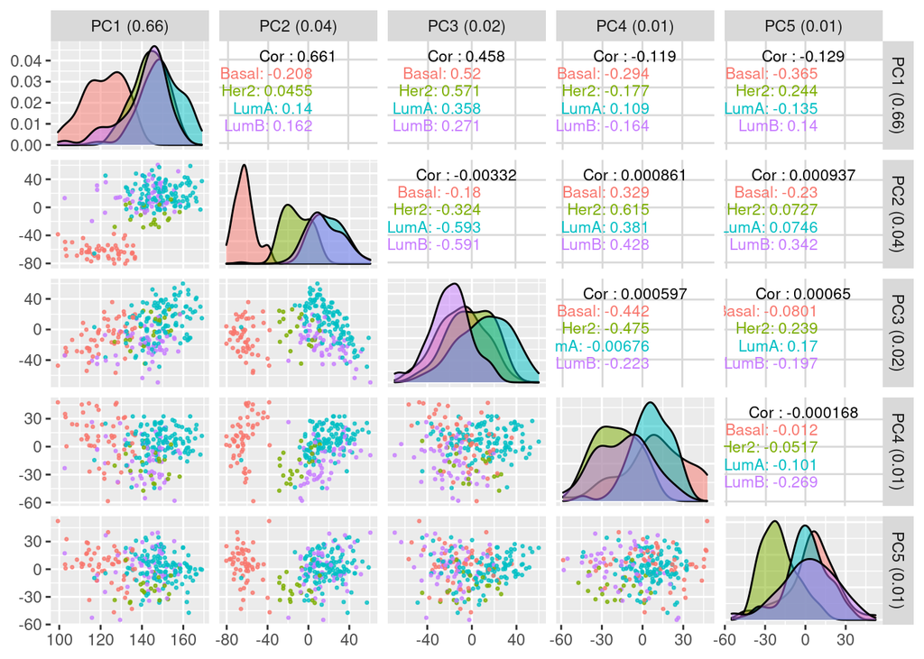

# Bibliography

The Cancer Genome Atlas Research Network. 2012. “Comprehensive Molecular Portraits of Human Breast Tumours.” *Nature* 490 (7418). Nature Publishing Group: 61.